# Numerical Processing in Python with NumPy

Python is convenient to program in, but can be slow. NumPy provides an n-dimensional array and a number of optimized routines to speed up computation.

```python
%matplotlib inline
import numpy as np
import matplotlib.pyplot as plt
```

```python
x = np.array([1,2,3])
x
```

```
array([1, 2, 3])
```

```python
x = np.array([1.0, 2.0, 3])
x
```

```
array([ 1.,  2.,  3.])
```

```python
x = np.array([1, 'two'])
x
```

```
array(['1', 'two'],
      dtype='|S21')
```

```python
x = np.array([[1, 2], [3, 4]])
x
```

```
array([[1, 2],
       [3, 4]])
```

```python
x.ndim
```

```
2
```

```python
x.shape
```

```
(2, 2)
```

NumPy provides a number of convenient array constructors. `arange` gives us the NumPy equivalent of Python's built-in `range` function:

```python
np.arange(10)
```

```
array([0, 1, 2, 3, 4, 5, 6, 7, 8, 9])
```

```python
np.arange(10.0)
```

```
array([ 0.,  1.,  2.,  3.,  4.,  5.,  6.,  7.,  8.,  9.])
```

```python
np.arange(1, 5)
```

```
array([1, 2, 3, 4])
```

```python
np.arange(1, 5, .2)
```

```
array([ 1. ,  1.2,  1.4,  1.6,  1.8,  2. ,  2.2,  2.4,  2.6,  2.8,  3. ,
        3.2,  3.4,  3.6,  3.8,  4. ,  4.2,  4.4,  4.6,  4.8])
```

```python
from datetime import date
np.arange(date(2016,4,1), date(2016,4,16))
```

```
array(['2016-04-01', '2016-04-02', '2016-04-03', '2016-04-04',
       '2016-04-05', '2016-04-06', '2016-04-07', '2016-04-08',
       '2016-04-09', '2016-04-10', '2016-04-11', '2016-04-12',
       '2016-04-13', '2016-04-14', '2016-04-15'], dtype='datetime64[D]')
```

NumPy also provides convenient `r_`, `c_`, and `mgrid` objects that concatenate objects to produce arrays:

```python
np.r_[1, 2, 3]
```

```
array([1, 2, 3])
```

```python
np.c_[1,2,3]
```

```
array([[1, 2, 3]])
```

```python
np.r_[[1,2,3], [4, 5, 6]]
```

```
array([1, 2, 3, 4, 5, 6])
```

```python
np.c_[[1, 2, 3], [4, 5, 6]]
```

```
array([[1, 4],
       [2, 5],
       [3, 6]])
```

```python
np.r_[1:4, 5, [6] * 4]
```

```
array([1, 2, 3, 5, 6, 6, 6, 6])
```

```python
np.r_[0:10:20j]
```

```
array([  0.        ,   0.52631579,   1.05263158,   1.57894737,
         2.10526316,   2.63157895,   3.15789474,   3.68421053,
         4.21052632,   4.73684211,   5.26315789,   5.78947368,
         6.31578947,   6.84210526,   7.36842105,   7.89473684,
         8.42105263,   8.94736842,   9.47368421,  10.        ])
```

```python
np.r_[0:10:1]
```

```
array([0, 1, 2, 3, 4, 5, 6, 7, 8, 9])
```

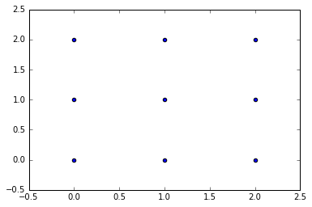

```python
xs, ys = np.mgrid[0:3, 0:3]
plt.scatter(xs, ys)
plt.show()
```

We can also do multidimensional arrays with `arange` using the `reshape` method:

```python
x = np.arange(16)
x.reshape(4,4)
```

```
array([[ 0,  1,  2,  3],
       [ 4,  5,  6,  7],
       [ 8,  9, 10, 11],
       [12, 13, 14, 15]])
```

NumPy also provides some special array constructors `zeros()`, `ones()`, `empty()`, and `eye()`

```python
np.zeros((3,3))
```

```
array([[ 0.,  0.,  0.],
       [ 0.,  0.,  0.],
       [ 0.,  0.,  0.]])
```

```python
np.ones((2,2))
```

```
array([[ 1.,  1.],
       [ 1.,  1.]])
```

```python
np.empty(10)    # unininitialized, not guaranteed to be zero
```

```
array([ 0.,  0.,  1.,  0.,  1.,  1.,  0.,  1.,  0.,  0.])
```

```python
np.empty((2,2))
```

```
array([[ 1.,  1.],
       [ 1.,  1.]])
```

```python
np.eye(4)
```

```
array([[ 1.,  0.,  0.,  0.],
       [ 0.,  1.,  0.,  0.],
       [ 0.,  0.,  1.,  0.],
       [ 0.,  0.,  0.,  1.]])
```

## NumPy Functions

Most of your standard math functions are available in the `numpy` package. In addition, `numpy` applies regular python operators to arrays in an element-by-element manner:

```python
xs = np.arange(10)
ys = np.arange(0, 5, 0.5)
xs, ys
```

```
(array([0, 1, 2, 3, 4, 5, 6, 7, 8, 9]),
 array([ 0. ,  0.5,  1. ,  1.5,  2. ,  2.5,  3. ,  3.5,  4. ,  4.5]))
```

```python
xs + ys
```

```
array([  0. ,   1.5,   3. ,   4.5,   6. ,   7.5,   9. ,  10.5,  12. ,  13.5])
```

```python
xs + 5
```

```
array([ 5,  6,  7,  8,  9, 10, 11, 12, 13, 14])
```

```python
np.sin(xs)
```

```
array([ 0.        ,  0.84147098,  0.90929743,  0.14112001, -0.7568025 ,
       -0.95892427, -0.2794155 ,  0.6569866 ,  0.98935825,  0.41211849])
```

```python
xs * ys
```

```
array([  0. ,   0.5,   2. ,   4.5,   8. ,  12.5,  18. ,  24.5,  32. ,  40.5])
```

If you'd rather have the dot product, you can use the `.dot()` method on arrays:

```python
xs.dot(ys)
```

```
142.5
```

Likewise with matrix multiplication:

```python
xs = np.arange(4).reshape((2,2))
xs
```

```
array([[0, 1],
       [2, 3]])
```

```python
xs.dot(xs)
```

```
array([[ 2,  3],
       [ 6, 11]])
```

We can also do simple statistics:

```python
xs = np.random.random(8)
xs
```

```
array([ 0.02414993,  0.04698722,  0.81574132,  0.32104562,  0.10176491,
        0.04335244,  0.16322729,  0.36338429])
```

```python
xs.sum()
```

```
1.8796530131959894
```

```python
xs.std()
```

```
0.25014623061910773
```

```python
xs.var()
```

```
0.062573136692947826
```

```python
xs.min()
```

```
0.024149926904244556
```

```python
xs.max()
```

```
0.81574131710289777
```

```python
xs.cumsum()
```

```
array([ 0.02414993,  0.07113714,  0.88687846,  1.20792408,  1.30968899,
        1.35304143,  1.51626872,  1.87965301])
```

## ufuncs

The familiar `math` functions that are implemented in NumPy are referred to as *universal functions* or *ufuncs*. Amongst these are trigonometric functions (`sin()`, `cos()`, etc.), `exp()`, `sqrt()`, etc.

```python
np.sin(xs)
```

```
array([ 0.02414758,  0.04696993,  0.72823384,  0.31555893,  0.10158935,
        0.04333886,  0.16250344,  0.35543956])
```

```python
np.exp(xs)
```

```
array([ 1.0244439 ,  1.04810861,  2.26085106,  1.37856847,  1.10712316,
        1.04430589,  1.17730425,  1.43818843])
```

```python
np.sqrt(xs)
```

```
array([ 0.15540247,  0.21676535,  0.90318399,  0.56660888,  0.31900612,
        0.2082125 ,  0.40401398,  0.60281364])
```

## Vectorization of pure Python

NumPy allows you to make your scalar Python functions act like NumPy *ufuncs*:

```python
def addsub(a, b):
    if a > b:
        return a - b
    else:
        return b + a
v_addsub = np.vectorize(addsub)
```

```python
xs = np.arange(5)
xs
```

```
array([0, 1, 2, 3, 4])
```

```python
v_addsub(xs, 3)
```

```
array([3, 4, 5, 6, 1])
```

## Array slicing

NumPy arrays allow for flexible slicing operations:

```python
xs = np.random.random((4, 5))
xs
```

```
array([[ 0.07277991,  0.95520205,  0.43161692,  0.70151709,  0.92516038],
       [ 0.86244814,  0.93618196,  0.14629332,  0.33816453,  0.69483296],
       [ 0.32530017,  0.57118541,  0.89095978,  0.40567961,  0.43955819],
       [ 0.96904728,  0.52626252,  0.41913634,  0.92376616,  0.53135101]])
```

```python
# Select a column
xs[:,1]
```

```
array([ 0.95520205,  0.93618196,  0.57118541,  0.52626252])
```

```python
# Select a row
xs[1, :]
```

```
array([ 0.86244814,  0.93618196,  0.14629332,  0.33816453,  0.69483296])
```

```python
# Select even rows and odd columns
xs[::2, 1::2]
```

```
array([[ 0.95520205,  0.70151709],
       [ 0.57118541,  0.40567961]])
```

```python
# Select specific columns
xs[:, [0,1,2]]
```

```
array([[ 0.07277991,  0.95520205,  0.43161692],
       [ 0.86244814,  0.93618196,  0.14629332],
       [ 0.32530017,  0.57118541,  0.89095978],
       [ 0.96904728,  0.52626252,  0.41913634]])
```

### Array reshaping and resizing

NumPy tries to be efficient about copying arrays (i.e. not copying data when it doesn't need to)

```python
xs = np.arange(16).reshape((4,4))
xs
```

```
array([[ 0,  1,  2,  3],
       [ 4,  5,  6,  7],
       [ 8,  9, 10, 11],
       [12, 13, 14, 15]])
```

```python
ys = xs
ys is xs
```

```
True
```

```python
ys.shape = 2,8
ys is xs
```

```
True
```

```python
xs
```

```
array([[ 0,  1,  2,  3,  4,  5,  6,  7],
       [ 8,  9, 10, 11, 12, 13, 14, 15]])
```

```python
xs.shape = 4,4
ys = xs.reshape((2,-1))
ys is xs
```

```
False
```

```python
xs
```

```
array([[ 0,  1,  2,  3],
       [ 4,  5,  6,  7],
       [ 8,  9, 10, 11],
       [12, 13, 14, 15]])
```

```python
ys
```

```
array([[ 0,  1,  2,  3,  4,  5,  6,  7],
       [ 8,  9, 10, 11, 12, 13, 14, 15]])
```

```python
ys = xs.view()
xs is ys
```

```
False
```

```python
xs.base is ys.base
```

```
True
```

```python
ys.shape = 2,8
xs
```

```
array([[ 0,  1,  2,  3],
       [ 4,  5,  6,  7],
       [ 8,  9, 10, 11],
       [12, 13, 14, 15]])
```

```python
ys
```

```
array([[ 0,  1,  2,  3,  4,  5,  6,  7],
       [ 8,  9, 10, 11, 12, 13, 14, 15]])
```

```python
xs.ravel()
```

```
array([ 0,  1,  2,  3,  4,  5,  6,  7,  8,  9, 10, 11, 12, 13, 14, 15])
```

## Plotting with matplotlib

```python
xs = np.arange(0, 2 * np.pi, 0.01)
```

```python
ys = np.sin(xs)
```

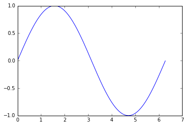

```python
plt.plot(xs, ys)
```

## Simple (and quick) statistics

NumPy also provides some simple and optimized statistics functions:

```python
mu = 2.0
sigma = 0.5
xs = np.random.normal(mu, sigma, 10000)
xs
```

```
array([ 2.59378901,  2.97386011,  2.19917993, ...,  2.27597774,
        2.21266282,  1.83051548])
```

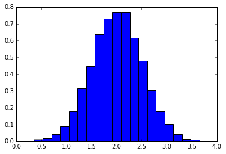

```python
plt.hist(xs, bins=20, normed=1)
plt.show()
```

```python
hist, edges = np.histogram(xs, bins=20, normed=1)
```

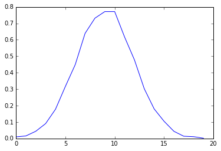

```python
plt.plot(hist)
plt.show()
```

### Exercises

- Create a 50x50 array with random values and find the minimum and maximum values.
- Find only the unique rows in array `a`.

  ```
    a = np.array([
              [1, 1, 1, 0, 0, 0],
              [1, 1, 0, 0, 0, 0],
              [1, 1, 1, 0, 0, 0],
              [0, 1, 1, 1, 0, 0],
              [0, 1, 1, 1, 0, 0],
              [1, 1, 1, 0, 0, 0],
              [1, 1, 1, 1, 1, 0]])
  ```

### Further Reading:

- You could often be dealing with large data files which cannot be loaded into memory. Numpy's `memmap` module allows you access small segments of a file at a time, with segment size customized by the `offset` parameter.

  See http://docs.scipy.org/doc/numpy/reference/generated/numpy.memmap.html for guidance.